# Exploratory Analysis - Diabetes Dataset Insights

Februar 10, 2025

# Load libraries

```r
library(tidyverse)
library(here)
library(skimr)
library(conflicted)
library(ggplot2)
library(magrittr)
library(plyr)
library(dplyr)
library(gridExtra)
library(stringr)
library(scales)
```

## Dataset description

[Source](https://www.kaggle.com/datasets/hasibur013/diabetes-dataset)

This dataset is originally adapted from the **National Institute of Diabetes and Digestive and Kidney Diseases (NIDDK)**. It contains medical measurements used to predict diabetes onset based on health factors. The dataset includes 768 records of female patients, each with 8 health-related attributes.

The **“Outcome”** column indicates if the patient has diabetes (1) or not (0). It is suitable for training and testing machine learning models for diabetes classification.

### Dataset Features:

- **Pregnancies**: Number of pregnancies.
- **Glucose**: Plasma glucose levels from a 2-hour glucose tolerance test.
- **BloodPressure**: Diastolic blood pressure (mm Hg).
- **SkinThickness**: Triceps skinfold thickness (mm).
- **Insulin**: 2-hour serum insulin (mu U/ml).
- **BMI**: Body mass index (kg/m²).
- **DiabetesPedigreeFunction**: Diabetes risk based on family history.
- **Age**: Patient’s age (years).
- **Outcome**: 1 for diabetes, 0 for no diabetes.

# Load Data

```r
diabetes_raw=read.csv("C:/Users/kawta/Desktop/Module/Data Science/Diabetes/subfolder/diabetes_dataset.csv")
```

# Cleaning and Prepping the Data

```r
# Load necessary libraries
library(dplyr)

# Assign the raw data to a new variable
diabetes <- diabetes_raw

# Outcome is a categorical variable with values 0 or 1, convert it to a factor
diabetes$Outcome <- factor(diabetes$Outcome)

# Spell out the Outcome flag (1 = Diabetes, 0 = healthy)
diabetes$Outcome <- ifelse(diabetes$Outcome == "1", "Diabetes", "healthy")

# Rename the 'Outcome' column to 'target'
colnames(diabetes)[ncol(diabetes)] <- "target"

# Entfernen der 0-Werte aus der SkinThickness-Spalte
diabetes$SkinThickness[diabetes$SkinThickness == 0] <- NA

# Create two subsets: diabetes patients and healthy individuals
diabetes_patients <- subset(diabetes, target == "Diabetes")
diabetes_healthy <- subset(diabetes, target == "healthy")

# Ensure Insulin is numeric and replace 0 values with NA
diabetes$Insulin <- as.numeric(diabetes$Insulin)
diabetes$Insulin[diabetes$Insulin == 0] <- NA

# Cleaning the Blood Pressure Data: Replace 0 values with NA
diabetes$BloodPressure[diabetes$BloodPressure == 0] <- NA

# Check the number of missing values in the Blood Pressure column
sum(is.na(diabetes$BloodPressure))
```

```
## [1] 35
```

```r
#  replacing NA values in BloodPressure with the median (as a simple imputation strategy):
diabetes$BloodPressure <- ifelse(is.na(diabetes$BloodPressure),
                                  median(diabetes$BloodPressure, na.rm = TRUE),
                                  diabetes$BloodPressure)
# Entfernen der 0-Werte aus den Spalten Glucose und BMI
diabetes$Glucose[diabetes$Glucose == 0] <- NA
diabetes$BMI[diabetes$BMI == 0] <- NA

# Optional: Überprüfen der Anzahl der fehlenden Werte in Glucose und BMI
sum(is.na(diabetes$Glucose))
```

```
## [1] 5
```

```r
sum(is.na(diabetes$BMI))
```

```
## [1] 11
```

# Descriptive Statistics

Show first 6 rows.

```r
head(diabetes)
```

```
##   Pregnancies Glucose BloodPressure SkinThickness Insulin  BMI
## 1           6     148            72            35      NA 33.6
## 2           1      85            66            29      NA 26.6
## 3           8     183            64            NA      NA 23.3
## 4           1      89            66            23      94 28.1
## 5           0     137            40            35     168 43.1
## 6           5     116            74            NA      NA 25.6
##   DiabetesPedigreeFunction Age   target
## 1                    0.627  50 Diabetes
## 2                    0.351  31  healthy
## 3                    0.672  32 Diabetes
## 4                    0.167  21  healthy
## 5                    2.288  33 Diabetes
## 6                    0.201  30  healthy
```

Show structure information about the dataframe.

```r
str(diabetes)
```

```
## 'data.frame':    768 obs. of  9 variables:
##  $ Pregnancies             : int  6 1 8 1 0 5 3 10 2 8 ...
##  $ Glucose                 : int  148 85 183 89 137 116 78 115 197 125 ...
##  $ BloodPressure           : int  72 66 64 66 40 74 50 72 70 96 ...
##  $ SkinThickness           : int  35 29 NA 23 35 NA 32 NA 45 NA ...
##  $ Insulin                 : num  NA NA NA 94 168 NA 88 NA 543 NA ...
##  $ BMI                     : num  33.6 26.6 23.3 28.1 43.1 25.6 31 35.3 30.5 NA ...
##  $ DiabetesPedigreeFunction: num  0.627 0.351 0.672 0.167 2.288 ...
##  $ Age                     : int  50 31 32 21 33 30 26 29 53 54 ...
##  $ target                  : chr  "Diabetes" "healthy" "Diabetes" "healthy" ...
```

Show summary statistics per column.

```r
summary(diabetes)
```

```
##   Pregnancies        Glucose      BloodPressure    SkinThickness
##  Min.   : 0.000   Min.   : 44.0   Min.   : 24.00   Min.   : 7.00
##  1st Qu.: 1.000   1st Qu.: 99.0   1st Qu.: 64.00   1st Qu.:22.00
##  Median : 3.000   Median :117.0   Median : 72.00   Median :29.00
##  Mean   : 3.845   Mean   :121.7   Mean   : 72.39   Mean   :29.15
##  3rd Qu.: 6.000   3rd Qu.:141.0   3rd Qu.: 80.00   3rd Qu.:36.00
##  Max.   :17.000   Max.   :199.0   Max.   :122.00   Max.   :99.00
##                   NA's   :5                        NA's   :227
##     Insulin            BMI        DiabetesPedigreeFunction      Age
##  Min.   : 14.00   Min.   :18.20   Min.   :0.0780           Min.   :21.00
##  1st Qu.: 76.25   1st Qu.:27.50   1st Qu.:0.2437           1st Qu.:24.00
##  Median :125.00   Median :32.30   Median :0.3725           Median :29.00
##  Mean   :155.55   Mean   :32.46   Mean   :0.4719           Mean   :33.24
##  3rd Qu.:190.00   3rd Qu.:36.60   3rd Qu.:0.6262           3rd Qu.:41.00
##  Max.   :846.00   Max.   :67.10   Max.   :2.4200           Max.   :81.00
##  NA's   :374      NA's   :11
##     target
##  Length:768
##  Class :character
##  Mode  :character
##
##
##
##
```

# Univariate Plots

In this section , we will visualize the distribution and key characteristics of a single variable. These plots help quickly identify patterns, trends, outliers, or any anomalies in the data.

## Pregnancies Distribution by Response

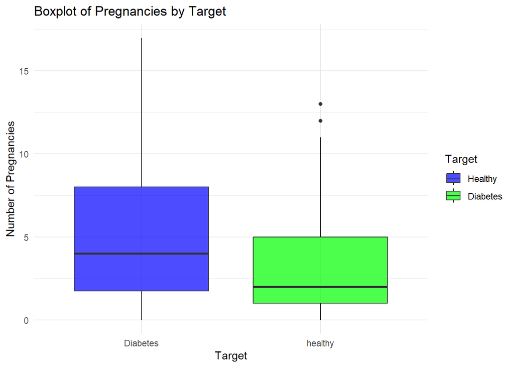

```r
ggplot(diabetes, aes(x = factor(target), y = Pregnancies, fill = factor(target))) +
  geom_boxplot(alpha = 0.7) +
  scale_fill_manual(values = c("blue", "green"),
                    labels = c("Healthy", "Diabetes")) +
  labs(title = "Boxplot of Pregnancies by Target",
       x = "Target",
       y = "Number of Pregnancies",
       fill = "Target") +
  theme_minimal()
```

```r
pregnancies_pvalue = t.test(diabetes_patients$Pregnancies, diabetes_healthy$Pregnancies)$p.value
```

**Interpretation:**

The median number of pregnancies is higher for individuals with diabetes compared to healthy individuals, as shown by the relative position of the central lines in each box.Outliers in the healthy group suggest that while most have fewer pregnancies, a small number have significantly higher counts. The p value 6.82192560045718e-09 is close to 0 indicating the results did not occur by chance .

## Glucose distribution

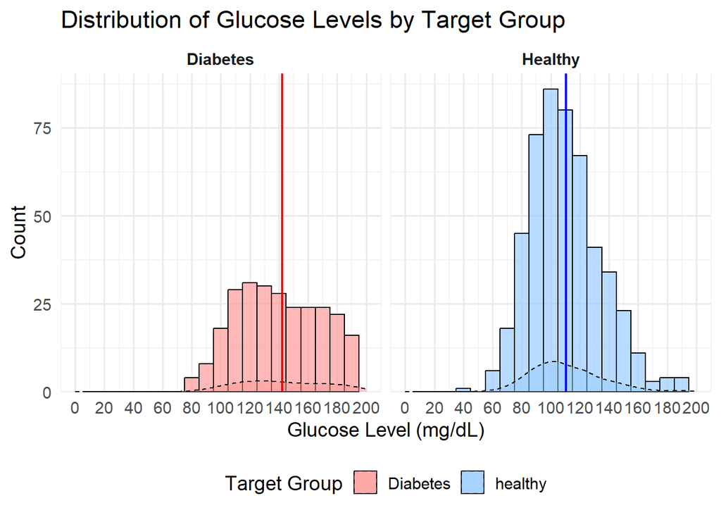

```r
# Improved histogram with additional enhancements using diabetes
diabetes %>%
  ggplot(aes(x = Glucose, fill = target)) +
  geom_histogram(binwidth = 10, color = "black", alpha = 0.7, position = "identity") +  # Histogram with transparency
  geom_density(aes(y = ..count..), color = "black", linetype = "dashed", alpha = 0.5) +  # Density overlay
  facet_wrap(~ target, ncol = 2, labeller = labeller(target = c(Diabetes = "Diabetes", healthy = "Healthy"))) +
  theme_minimal(base_size = 14) +  # Cleaner theme
  theme(
    strip.text = element_text(face = "bold"),  # Bold facet labels
    legend.position = "bottom"  # Move legend to the bottom
  ) +
  labs(
    title = "Distribution of Glucose Levels by Target Group",
    x = "Glucose Level (mg/dL)",
    y = "Count",
    fill = "Target Group"
  ) +
  scale_x_continuous(limits = c(0, 200), breaks = seq(0, 200, 20)) +  # Set axis limits and breaks
  scale_y_continuous(expand = expansion(mult = c(0, 0.05))) +  # Avoid excessive y-axis margin
  scale_fill_manual(values = c("Diabetes" = "#FF9999", "healthy" = "#99CCFF")) +  # Custom colors
  geom_vline(data = diabetes %>% group_by(target) %>% dplyr::summarize(mean_glucose = mean(Glucose, na.rm = TRUE)),
             aes(xintercept = mean_glucose, color = target),
             linetype = "solid", size = 0.8) +  # Add mean lines
  scale_color_manual(values = c("Diabetes" = "red", "healthy" = "blue"), guide = "none")  # Mean line colors
```

**Interpretation:**

The histogram shows that healthy individuals have glucose levels concentrated between 80–120 mg/dL, with a mean around 100 mg/dL, while individuals with diabetes have higher glucose levels, typically between 120–180 mg/dL, with a mean near 140 mg/dL.

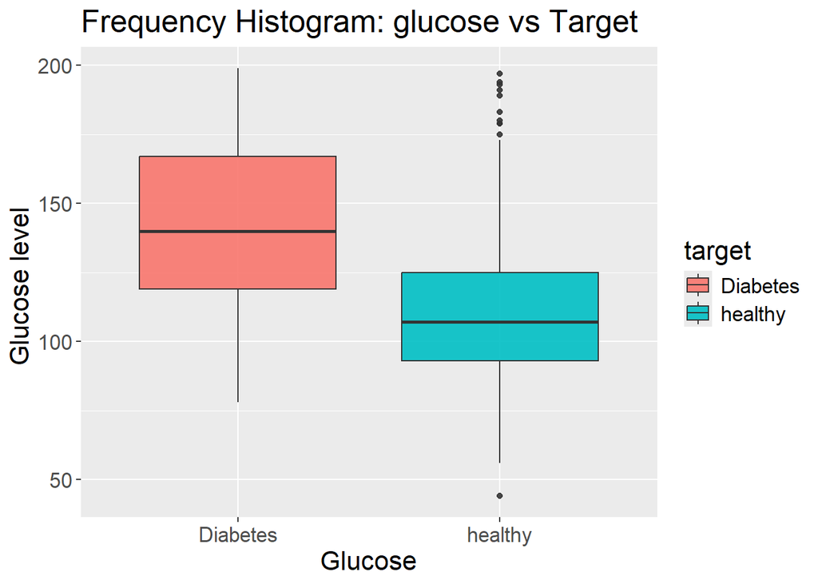

```r
diabetes %>%
  ggplot( aes(x = target ,y= Glucose, fill = target)) +
    geom_boxplot(alpha = 0.9)+
    theme(text = element_text(size=16)) +
    labs ( title = "Frequency Histogram: glucose vs Target" ) +
          xlab ("Glucose") +
          ylab ("Glucose level ")
```

```r
glucose_pvalue = t.test (diabetes_patients$Glucose, diabetes_healthy$Glucose)$p.value
```

**Interpretation:**

Patients with diabetes tend to have higher glucose levels compared to healthy individuals. Outliers in the “healthy” group suggest a few individuals have unusually high glucose levels, potentially indicating other factors at play.The p value 2.64416134954036e-36 very close to 0) indicates the observed difference in glucose levels between the “Diabetes” and “healthy” groups is statistically significant.

## Blood Pressure Distribution by Response

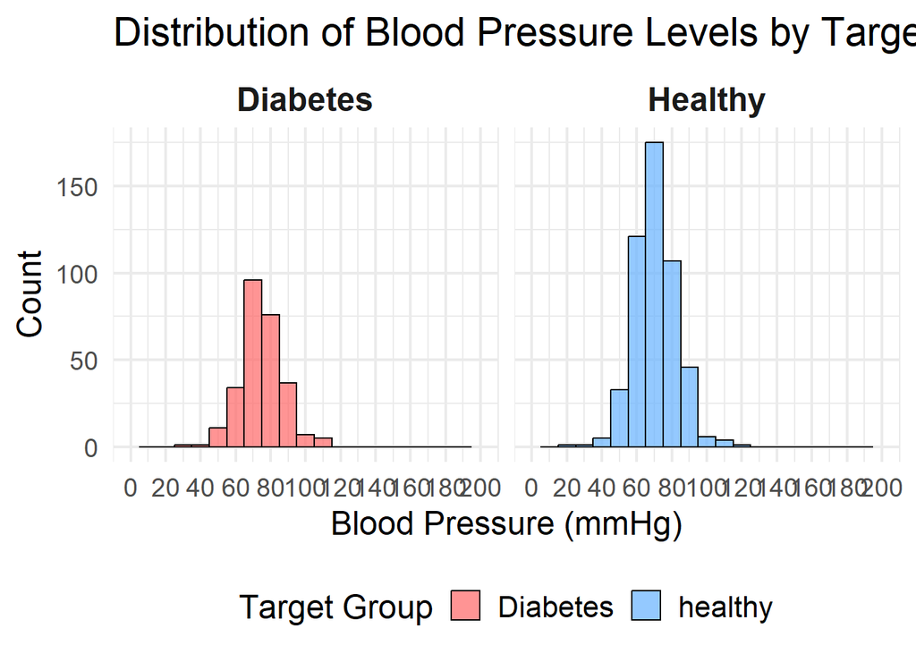

```r
diabetes %>%
  ggplot(aes(x = BloodPressure, fill = target)) +
    geom_histogram(binwidth = 10, color = "black", alpha = 0.7) +  # Increased binwidth for wider bins
    facet_wrap(~ target, labeller = labeller(target = c(Diabetes = "Diabetes", healthy = "Healthy"))) +
    theme_minimal(base_size = 18) +  # Larger base font size for better readability
    theme(
      strip.text = element_text(face = "bold", size = 18),  # Bold facet labels with larger size
      legend.position = "bottom",  # Move legend below
      legend.text = element_text(size = 16)  # Increase legend text size
    ) +
    labs(
      title = "Distribution of Blood Pressure Levels by Target Group",
      x = "Blood Pressure (mmHg)",
      y = "Count",
      fill = "Target Group"
    ) +
    scale_x_continuous(limits = c(0, 200), breaks = seq(0, 200, 20)) +  # Adjust x-axis limits and breaks
    scale_fill_manual(values = c("Diabetes" = "#FF6666", "healthy" = "#66B2FF"))  # Custom vibrant colors
```

**Interpretation:**

Blood pressure values range from approximately 25 mmHg to 120 mmHg, with the majority falling between 50 and 90 mmHg . A few individuals have blood pressure values below 50 mmHg or above 100 mmHg .

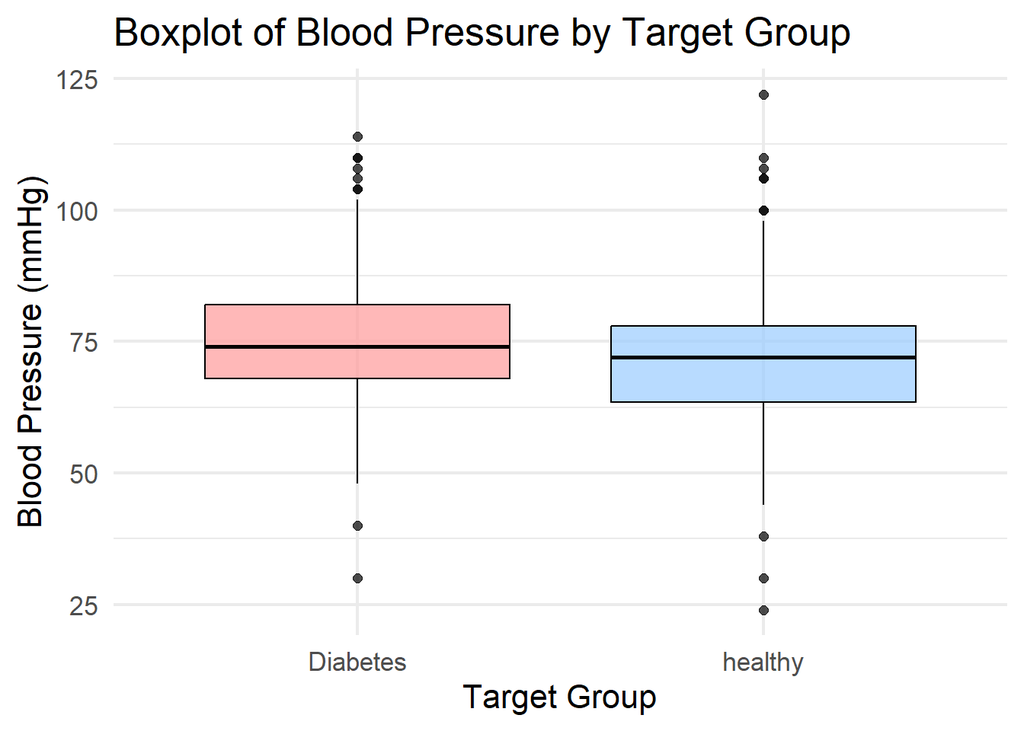

```r
diabetes %>%
  ggplot(aes(x = target, y = BloodPressure, fill = target)) +
    geom_boxplot(alpha = 0.7, color = "black", outlier.size = 2) +  # Boxplot with borders and visible outliers
    theme_minimal(base_size = 16) +  # Cleaner theme and larger font size
    theme(
      legend.position = "none",  # Remove legend since target is on x-axis
      strip.text = element_text(face = "bold")  # Bold facet labels
    ) +
    labs(
      title = "Boxplot of Blood Pressure by Target Group",
      x = "Target Group",
      y = "Blood Pressure (mmHg)"
    ) +
    scale_fill_manual(values = c("Diabetes" = "#FF9999", "healthy" = "#99CCFF"))  # Custom colors
```

```r
bloodpressure_pvalue = t.test(diabetes_patients$BloodPressure, diabetes_healthy$BloodPressure)$p.value
```

## Skin Thickness Distribution

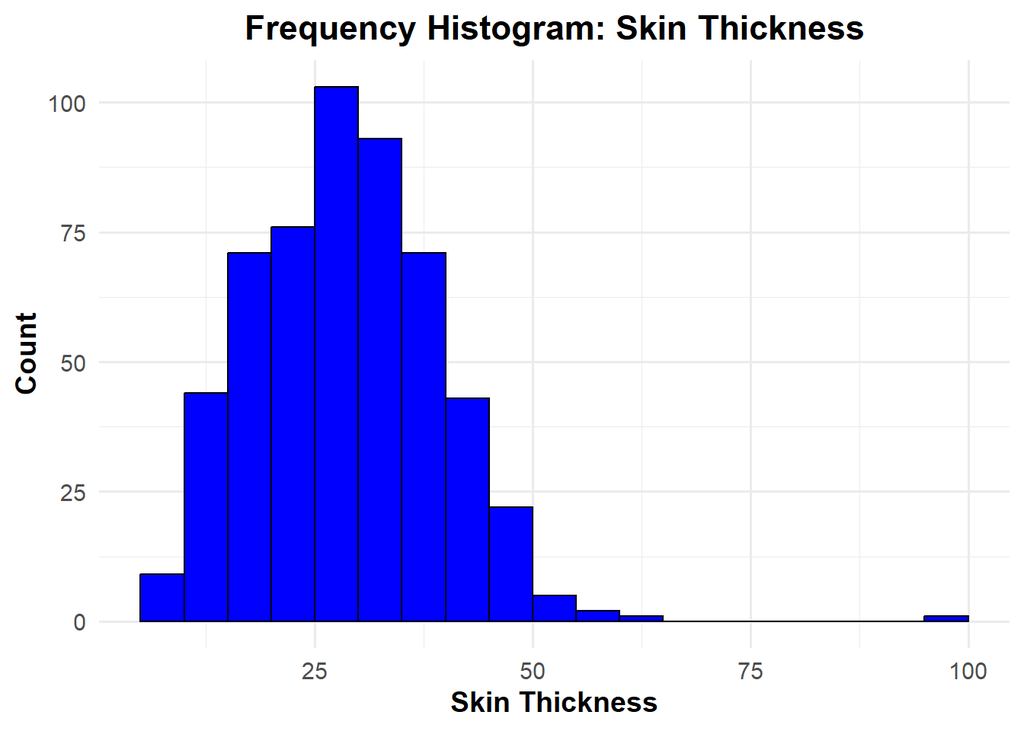

```r
ggplot(diabetes, aes(x = SkinThickness)) +
  geom_histogram(binwidth = 5, fill = "blue", color = "black", boundary = 0) +
  labs(
    title = "Frequency Histogram: Skin Thickness",
    x = "Skin Thickness",
    y = "Count"
  ) +
  theme_minimal(base_size = 14) +
  theme(
    plot.title = element_text(hjust = 0.5, face = "bold"),
    axis.title = element_text(face = "bold")
  )
```

**Interpretation:**

The most frequent skin thickness values fall between 20 and 35, where the count exceeds 75.

## Skin Thickness Distribution by Response

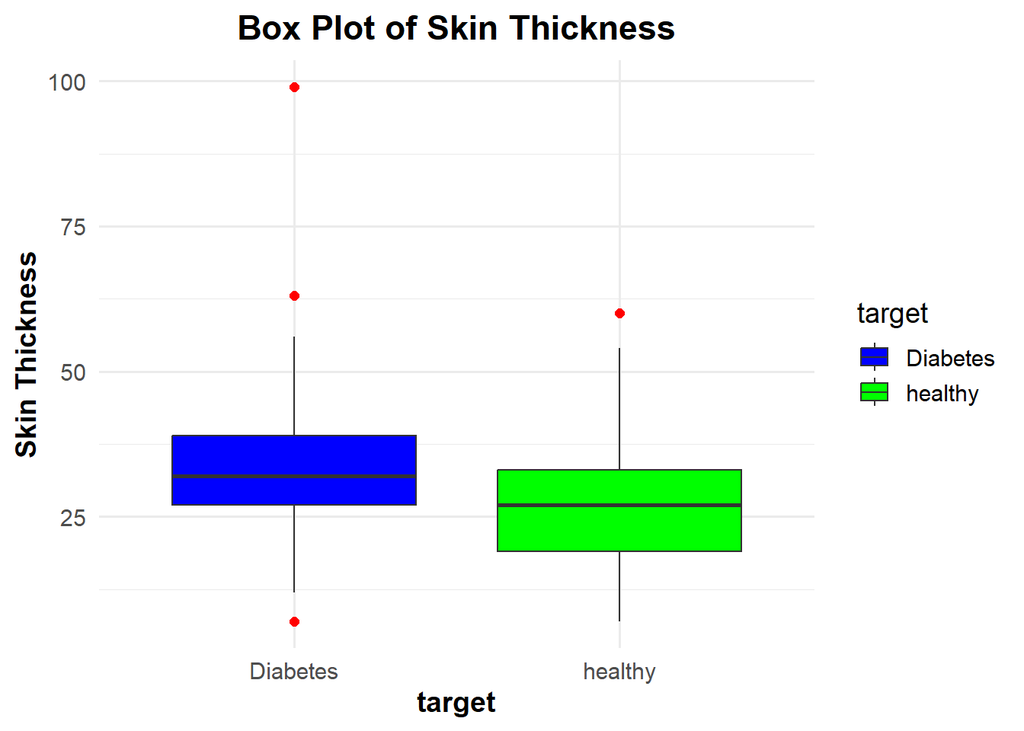

```r
ggplot(diabetes, aes(x = as.factor(target), y = SkinThickness, fill = as.factor(target))) +
  geom_boxplot(outlier.color = "red", outlier.size = 2) +
  labs(
    title = "Box Plot of Skin Thickness",
    x = "target",
    y = "Skin Thickness"
  ) +
  scale_fill_manual(values = c("blue", "green"), name = "target") +
  theme_minimal(base_size = 14) +
  theme(
    plot.title = element_text(hjust = 0.5, face = "bold"),
    axis.title = element_text(face = "bold")
  )
```

```r
skinthickness_pvalue = t.test(diabetes_patients$SkinThickness, diabetes_healthy$SkinThickness)$p.value
```

## Insulin Distribution by Response

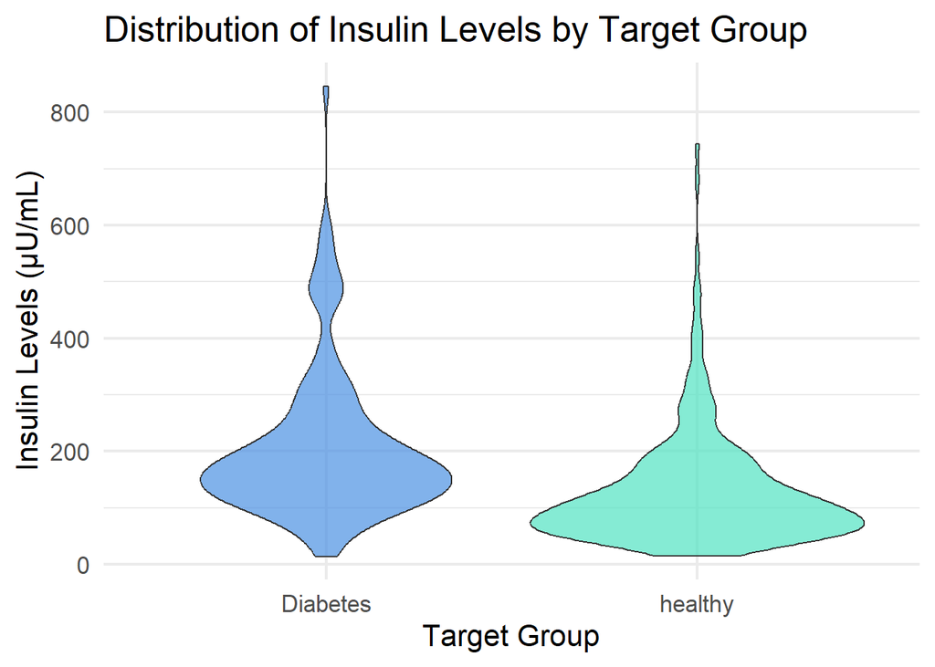

```r
# Filter rows with valid Insulin values for plotting
diabetes_clean <- diabetes %>%
  dplyr::filter(!is.na(Insulin))

# Use a violin plot to show the distribution of insulin levels
diabetes_clean %>%
  ggplot(aes(x = target, y = Insulin, fill = target)) +
  geom_violin(alpha = 0.7, trim = TRUE) +  # Violin plot with trimmed tails
  theme_minimal(base_size = 16) +
  theme(
    legend.position = "none",
    strip.text = element_text(face = "bold", size = 14)
  ) +
  labs(
    title = "Distribution of Insulin Levels by Target Group",
    x = "Target Group",
    y = "Insulin Levels (µU/mL)"
  ) +
  scale_fill_manual(values = c("Diabetes" = "#4A90E2", "healthy" = "#50E3C2"))
```

```r
# Perform a t-test to compare Insulin levels between the two groups
insulin_pvalue <- t.test(
  subset(diabetes_clean, target == "Diabetes")$Insulin,
  subset(diabetes_clean, target == "healthy")$Insulin
)$p.value
```

**Interpretation:** The “Diabetes” group (blue) shows a more spread-out distribution with a right skew, while the “Healthy” group (green) has a sharp peak near low insulin levels and tapers off quickly. The chart effectively conveys a difference in insulin distribution between the two groups, which might reflect underlying physiological differences, assuming the data is accurate. The p value 2.67211639987616e-08 suggests very strong evidence against the null hypothesis, assuming the standard significance threshold (e.g., 0.05). This means that the observed differences in insulin levels between the “Diabetes” and “Healthy” groups are highly unlikely to have occurred due to random chance.

## BMI Distribution by Response

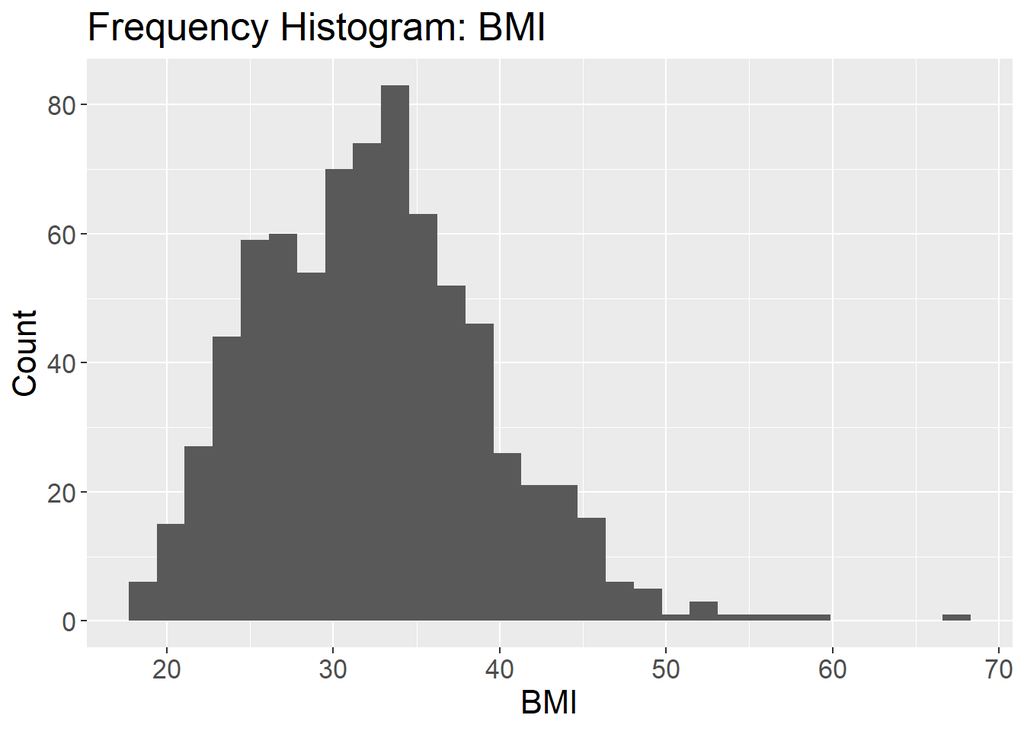

```r
diabetes %>%
  dplyr::filter(BMI != 0) %>%  # Remove rows where BMI is 0
  ggplot(aes(x = BMI, fill = BMI)) +
  geom_histogram() +
  theme(text = element_text(size = 16)) +
  labs(title = "Frequency Histogram: BMI") +
  xlab("BMI") +
  ylab("Count")
```

**Interpretation:**

Most BMI values ARE concentrated around 20–40, indicating a normal to overweight range.

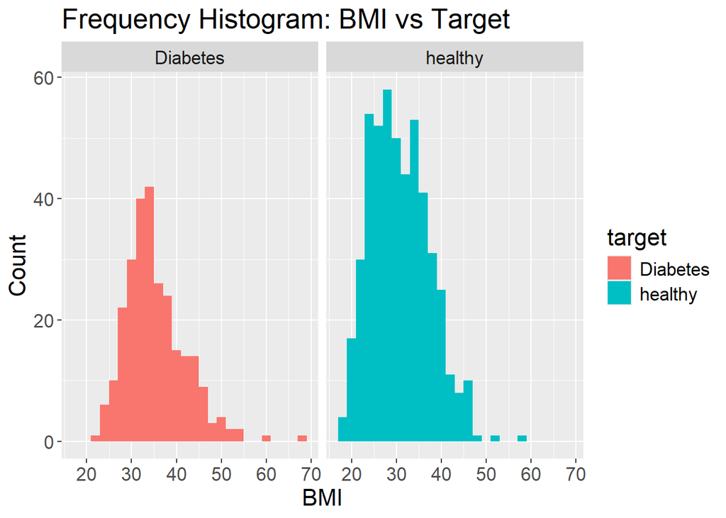

```r
# First plot: Histogram with BMI values, removing 0 BMI
diabetes %>%
  dplyr::filter(BMI != 0) %>%  # Remove rows where BMI is 0
  ggplot(aes(x = BMI, fill = target)) +
  geom_histogram(binwidth = 2) +
  facet_wrap(~ target) +
  theme(text = element_text(size = 16)) +
  labs(title = "Frequency Histogram: BMI vs Target") +
  xlab("BMI") +
  ylab("Count")
```

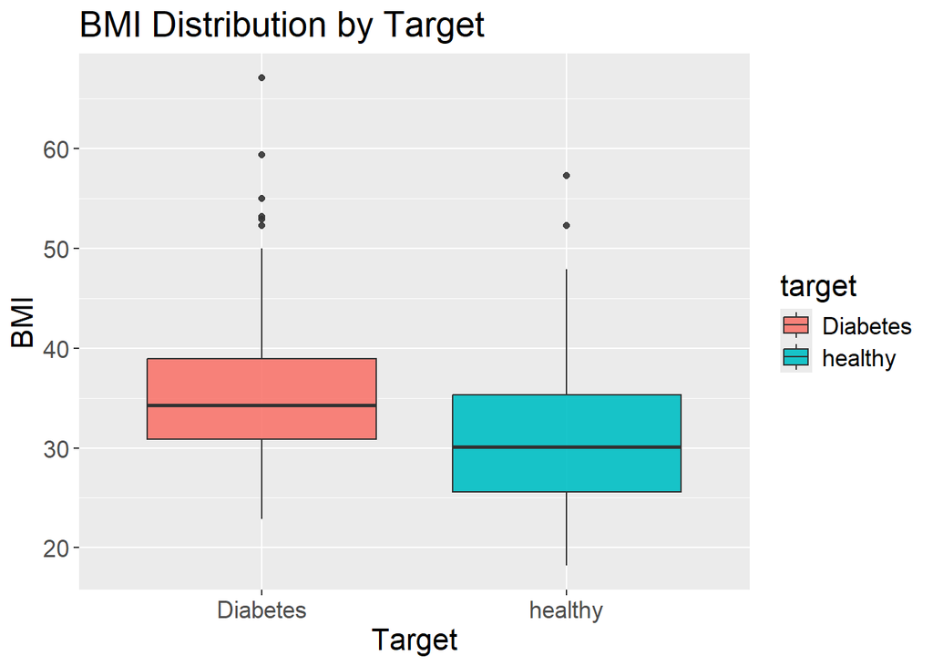

```r
# Second plot: Boxplot for BMI vs Target, removing 0 BMI
diabetes %>%
  dplyr::filter(BMI != 0) %>%  # Remove rows where BMI is 0
  ggplot(aes(x = target, y = BMI, fill = target)) +
  geom_boxplot(alpha = 0.9) +
  theme(text = element_text(size = 16)) +
  labs(title = "BMI Distribution by Target") +
  xlab("Target") +
  ylab("BMI")
```

```r
# Perform t-test to compare BMI between healthy and diabetic patients
BMI_pvalue = t.test(diabetes_healthy$BMI, diabetes_patients$BMI)$p.value
```

**Interpretation:**

Both groups have overlapping BMI ranges, the median BMI for the diabetes group appears slightly higher, suggesting a potential association between higher BMI and diabetes.The BMI p-value of 6.56623762470911e-17 is an extremely small value indicating that this result is highly statistically significant .

## Diabetes Pedigree Function Distribution by Response

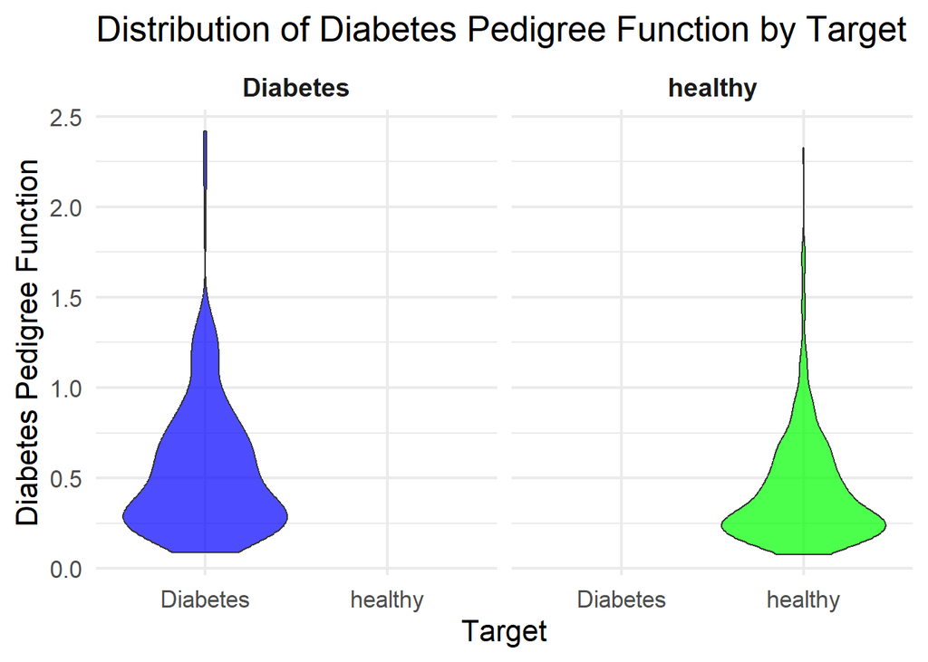

```r
# Remove 0 values and create a violin plot for Diabetes Pedigree Function
diabetes %>%
  dplyr::filter(DiabetesPedigreeFunction != 0) %>%  # Remove rows where DiabetesPedigreeFunction is 0
  ggplot(aes(x = factor(target), y = DiabetesPedigreeFunction, fill = factor(target))) +
  geom_violin(alpha = 0.7, trim = TRUE) +  # Violin plot for better distribution view
  scale_fill_manual(values = c("blue", "green"), labels = c("Healthy", "Diabetes")) +
  labs(
    title = "Distribution of Diabetes Pedigree Function by Target",
    x = "Target",
    y = "Diabetes Pedigree Function",
    fill = "Target"
  ) +
  facet_wrap(~target, labeller = labeller(target = c("0" = "Healthy", "1" = "Diabetes"))) +
  theme_minimal(base_size = 16) +
  theme(
    legend.position = "none",  # Remove legend
    strip.text = element_text(face = "bold", size = 14)
  )
```

```r
DiabetesPedigreeFunction_pvalue <- t.test(diabetes_patients$DiabetesPedigreeFunction, diabetes_healthy$DiabetesPedigreeFunction)$p.value
```

**Interpretation:**

individuals with diabetes (blue) tend to have higher Diabetes Pedigree Function values, indicating greater genetic predisposition compared to the healthy group (green). The healthy group has a concentrated distribution at lower values, while the diabetes group is more spread out with a right skew. There is some overlap at lower values, but the distinction becomes clearer as the function value increases. The p value 6.10048142424025e-06 suggests that the difference between the diabetes and healthy groups is highly statistically significant and is unlikely to have occurred due to random chance. Therefore, it supports the conclusion that individuals with diabetes have a significantly different (likely higher) Diabetes Pedigree Function compared to healthy individuals.

## Age Distribution

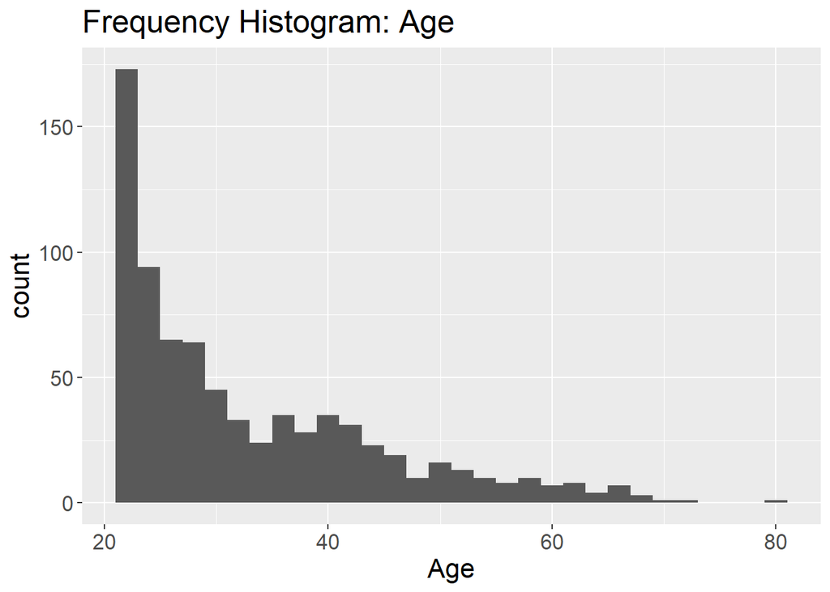

```r
# By Age
diabetes %>%
  ggplot( aes(x = Age)) +
    geom_histogram(binwidth =2)+
  theme(text = element_text(size=16)) +
    labs ( title = "Frequency Histogram: Age" )  +
          xlab ("Age") +
          ylab  ("count")
```

**Interpretation:**

the majority of the patients is concentrated around younger ages (20–30), with a gradual decrease in frequency as age increases.

## Age Distribution by Response

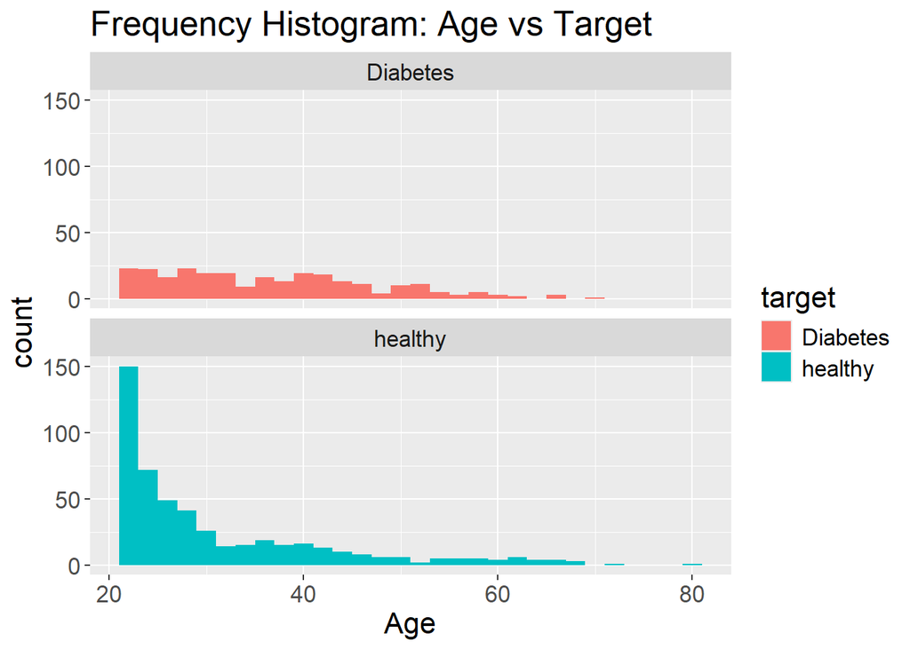

```r
# By Age and Target using histograms
diabetes %>%
  ggplot( aes(x = Age, fill = target)) +
    geom_histogram(binwidth =2)+
    facet_wrap(~ target, ncol=1) +
    theme(text = element_text(size=16)) +
    labs ( title = "Frequency Histogram: Age vs Target" ) +
          xlab ("Age") +
          ylab ("count")
```

```r
age_pvalue = t.test(diabetes_patients$Age, diabetes_healthy$Age)$p.value
```

**Interpretation:**

Patients with diabetes are spread relatively evenly across ages, while healthy individuals are more concentrated in younger age groups, with a sharp decline in frequency as age increases.

The age is statistical significant with a p-value of 1.20151252731134e-11.